# Risk Factor Analysis

## Outcome Variable

**Outcome Variable:** y_rate_len

## Predictor Variables

**Intervention Variable:** safeh20

**Adjustment Set:**

- arm
- sex
- W_mage
- meducyrs
- feducyrs
- hhwealth_quart
- hfoodsec
- W_mhtcm
- W_nrooms
- W_nchldlt5
- W_parity
- impfloor
- impsan
- delta_W_mage
- delta_meducyrs
- delta_feducyrs
- delta_hhwealth_quart
- delta_hfoodsec
- delta_W_mhtcm
- delta_W_nrooms
- delta_W_nchldlt5
- delta_W_parity
- delta_impfloor
- delta_impsan

## Stratifying Variables

The analysis was stratified on these variable(s):

- agecat
- studyid
- country

## Data Summary

| agecat | studyid | country | safeh20 | n_cell | n |
| --- | --- | --- | --- | --- | --- |
| 0-3 months | ki0047075b-MAL-ED | BANGLADESH | 0 | 237 | 237 |
| 0-3 months | ki1017093-NIH-Birth | BANGLADESH | 0 | 2 | 566 |
| 0-3 months | ki1017093-NIH-Birth | BANGLADESH | 1 | 564 | 566 |
| 0-3 months | ki1017093b-PROVIDE | BANGLADESH | 1 | 634 | 634 |
| 0-3 months | ki1017093c-NIH-Crypto | BANGLADESH | 1 | 720 | 720 |
| 0-3 months | kiGH5241-JiVitA-3 | BANGLADESH | 0 | 35 | 20029 |
| 0-3 months | kiGH5241-JiVitA-3 | BANGLADESH | 1 | 19994 | 20029 |
| 0-3 months | kiGH5241-JiVitA-4 | BANGLADESH | 1 | 1805 | 1805 |
| 0-3 months | ki0047075b-MAL-ED | BRAZIL | 0 | 124 | 124 |
| 0-3 months | ki0047075b-MAL-ED | INDIA | 0 | 194 | 194 |
| 0-3 months | ki0047075b-MAL-ED | NEPAL | 0 | 170 | 171 |
| 0-3 months | ki0047075b-MAL-ED | NEPAL | 1 | 1 | 171 |
| 0-3 months | ki0047075b-MAL-ED | PERU | 0 | 238 | 249 |
| 0-3 months | ki0047075b-MAL-ED | PERU | 1 | 11 | 249 |
| 0-3 months | ki1114097-CONTENT | PERU | 0 | 1 | 6 |
| 0-3 months | ki1114097-CONTENT | PERU | 1 | 5 | 6 |
| 0-3 months | ki0047075b-MAL-ED | SOUTH AFRICA | 0 | 180 | 213 |
| 0-3 months | ki0047075b-MAL-ED | SOUTH AFRICA | 1 | 33 | 213 |
| 0-3 months | ki0047075b-MAL-ED | TANZANIA, UNITED REPUBLIC OF | 0 | 70 | 225 |
| 0-3 months | ki0047075b-MAL-ED | TANZANIA, UNITED REPUBLIC OF | 1 | 155 | 225 |
| 3-6 months | ki0047075b-MAL-ED | BANGLADESH | 0 | 231 | 231 |
| 3-6 months | ki1017093-NIH-Birth | BANGLADESH | 0 | 2 | 523 |
| 3-6 months | ki1017093-NIH-Birth | BANGLADESH | 1 | 521 | 523 |
| 3-6 months | ki1017093b-PROVIDE | BANGLADESH | 1 | 572 | 572 |
| 3-6 months | ki1017093c-NIH-Crypto | BANGLADESH | 1 | 695 | 695 |
| 3-6 months | kiGH5241-JiVitA-3 | BANGLADESH | 0 | 12 | 12573 |
| 3-6 months | kiGH5241-JiVitA-3 | BANGLADESH | 1 | 12561 | 12573 |
| 3-6 months | kiGH5241-JiVitA-4 | BANGLADESH | 1 | 1839 | 1839 |
| 3-6 months | ki0047075b-MAL-ED | BRAZIL | 0 | 141 | 141 |
| 3-6 months | ki0047075b-MAL-ED | INDIA | 0 | 229 | 229 |

[output cut: 55 more lines]

The following strata were considered:

- agecat: 0-3 months, studyid: ki0047075b-MAL-ED, country: BANGLADESH
- agecat: 0-3 months, studyid: ki0047075b-MAL-ED, country: BRAZIL
- agecat: 0-3 months, studyid: ki0047075b-MAL-ED, country: INDIA
- agecat: 0-3 months, studyid: ki0047075b-MAL-ED, country: NEPAL
- agecat: 0-3 months, studyid: ki0047075b-MAL-ED, country: PERU
- agecat: 0-3 months, studyid: ki0047075b-MAL-ED, country: SOUTH AFRICA
- agecat: 0-3 months, studyid: ki0047075b-MAL-ED, country: TANZANIA, UNITED REPUBLIC OF
- agecat: 0-3 months, studyid: ki1017093-NIH-Birth, country: BANGLADESH
- agecat: 0-3 months, studyid: ki1017093b-PROVIDE, country: BANGLADESH
- agecat: 0-3 months, studyid: ki1017093c-NIH-Crypto, country: BANGLADESH
- agecat: 0-3 months, studyid: ki1114097-CONTENT, country: PERU
- agecat: 0-3 months, studyid: kiGH5241-JiVitA-3, country: BANGLADESH
- agecat: 0-3 months, studyid: kiGH5241-JiVitA-4, country: BANGLADESH
- agecat: 12-24 months, studyid: ki0047075b-MAL-ED, country: BANGLADESH
- agecat: 12-24 months, studyid: ki0047075b-MAL-ED, country: BRAZIL
- agecat: 12-24 months, studyid: ki0047075b-MAL-ED, country: INDIA
- agecat: 12-24 months, studyid: ki0047075b-MAL-ED, country: NEPAL
- agecat: 12-24 months, studyid: ki0047075b-MAL-ED, country: PERU
- agecat: 12-24 months, studyid: ki0047075b-MAL-ED, country: SOUTH AFRICA
- agecat: 12-24 months, studyid: ki0047075b-MAL-ED, country: TANZANIA, UNITED REPUBLIC OF
- agecat: 12-24 months, studyid: ki1017093-NIH-Birth, country: BANGLADESH
- agecat: 12-24 months, studyid: ki1017093b-PROVIDE, country: BANGLADESH
- agecat: 12-24 months, studyid: ki1017093c-NIH-Crypto, country: BANGLADESH
- agecat: 12-24 months, studyid: ki1114097-CONTENT, country: PERU
- agecat: 12-24 months, studyid: ki1148112-LCNI-5, country: MALAWI
- agecat: 12-24 months, studyid: kiGH5241-JiVitA-3, country: BANGLADESH
- agecat: 12-24 months, studyid: kiGH5241-JiVitA-4, country: BANGLADESH
- agecat: 3-6 months, studyid: ki0047075b-MAL-ED, country: BANGLADESH
- agecat: 3-6 months, studyid: ki0047075b-MAL-ED, country: BRAZIL
- agecat: 3-6 months, studyid: ki0047075b-MAL-ED, country: INDIA
- agecat: 3-6 months, studyid: ki0047075b-MAL-ED, country: NEPAL
- agecat: 3-6 months, studyid: ki0047075b-MAL-ED, country: PERU
- agecat: 3-6 months, studyid: ki0047075b-MAL-ED, country: SOUTH AFRICA
- agecat: 3-6 months, studyid: ki0047075b-MAL-ED, country: TANZANIA, UNITED REPUBLIC OF
- agecat: 3-6 months, studyid: ki1017093-NIH-Birth, country: BANGLADESH
- agecat: 3-6 months, studyid: ki1017093b-PROVIDE, country: BANGLADESH
- agecat: 3-6 months, studyid: ki1017093c-NIH-Crypto, country: BANGLADESH
- agecat: 3-6 months, studyid: ki1114097-CONTENT, country: PERU
- agecat: 3-6 months, studyid: kiGH5241-JiVitA-3, country: BANGLADESH
- agecat: 3-6 months, studyid: kiGH5241-JiVitA-4, country: BANGLADESH
- agecat: 6-12 months, studyid: ki0047075b-MAL-ED, country: BANGLADESH
- agecat: 6-12 months, studyid: ki0047075b-MAL-ED, country: BRAZIL
- agecat: 6-12 months, studyid: ki0047075b-MAL-ED, country: INDIA
- agecat: 6-12 months, studyid: ki0047075b-MAL-ED, country: NEPAL
- agecat: 6-12 months, studyid: ki0047075b-MAL-ED, country: PERU
- agecat: 6-12 months, studyid: ki0047075b-MAL-ED, country: SOUTH AFRICA
- agecat: 6-12 months, studyid: ki0047075b-MAL-ED, country: TANZANIA, UNITED REPUBLIC OF
- agecat: 6-12 months, studyid: ki1000304b-SAS-FoodSuppl, country: INDIA
- agecat: 6-12 months, studyid: ki1017093-NIH-Birth, country: BANGLADESH
- agecat: 6-12 months, studyid: ki1017093b-PROVIDE, country: BANGLADESH
- agecat: 6-12 months, studyid: ki1017093c-NIH-Crypto, country: BANGLADESH
- agecat: 6-12 months, studyid: ki1114097-CONTENT, country: PERU
- agecat: 6-12 months, studyid: ki1148112-LCNI-5, country: MALAWI
- agecat: 6-12 months, studyid: kiGH5241-JiVitA-3, country: BANGLADESH
- agecat: 6-12 months, studyid: kiGH5241-JiVitA-4, country: BANGLADESH

## Methods Detail

We’re interested in the causal parameters $E[Y_a]$ for all values of $a \in \mathcal{A}$. These parameters represent the mean outcome if, possibly contrary to fact, we intervened to set all units to have $A=a$. Under the randomization and positivity assumptions, these are identified by the statistical parameters $\psi_a=E_W[E_{Y|A,W}(Y|A=a,W)]$. In addition, we’re interested in the mean of $Y$, $E[Y]$ under no intervention (the observed mean). We will estimate these parameters by using SuperLearner to fit the relevant likelihood factors – $E_{Y|A,W}(Y|A=a,W)$ and $p(A=a|W)$, and then updating our likelihood fit using a joint TMLE.

For unadjusted analyses ($W=\{\}$), initial likelihoods were estimated using Lrnr_glm to estimate the simple $E(Y|A)$ and Lrnr_mean to estimate $p(A)$. For adjusted analyses, a small library containing Lrnr_glmnet, Lrnr_xgboost, and Lrnr_mean was used.

Having estimated these parameters, we will then use the delta method to estimate relative risks and attributable risks relative to a prespecified baseline level of $A$.

[output not shown]

[output cut: 11793 more lines]

[output not shown]

# Results Detail

## Results Plots

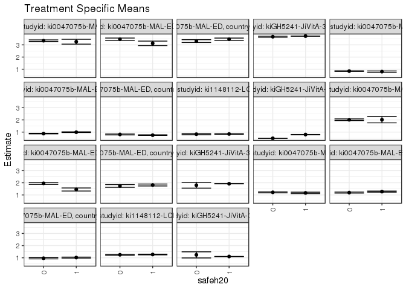

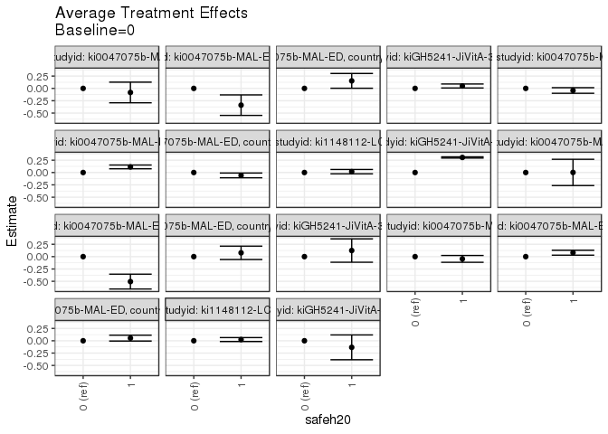

## Results Table

### Parameter: TSM

| agecat | studyid | country | intervention_level | baseline_level | estimate | ci_lower | ci_upper |
| --- | --- | --- | --- | --- | --- | --- | --- |
| 0-3 months | ki0047075b-MAL-ED | PERU | 0 | NA | 3.3426036 | 3.2760672 | 3.4091400 |
| 0-3 months | ki0047075b-MAL-ED | PERU | 1 | NA | 3.2599635 | 3.0617293 | 3.4581977 |
| 0-3 months | ki0047075b-MAL-ED | SOUTH AFRICA | 0 | NA | 3.4643204 | 3.3682677 | 3.5603732 |
| 0-3 months | ki0047075b-MAL-ED | SOUTH AFRICA | 1 | NA | 3.1248070 | 2.9395942 | 3.3100198 |
| 0-3 months | ki0047075b-MAL-ED | TANZANIA, UNITED REPUBLIC OF | 0 | NA | 3.3112867 | 3.1955288 | 3.4270445 |
| 0-3 months | ki0047075b-MAL-ED | TANZANIA, UNITED REPUBLIC OF | 1 | NA | 3.4639273 | 3.3685736 | 3.5592811 |
| 0-3 months | kiGH5241-JiVitA-3 | BANGLADESH | 0 | NA | 3.6699450 | 3.6304727 | 3.7094174 |
| 0-3 months | kiGH5241-JiVitA-3 | BANGLADESH | 1 | NA | 3.7186612 | 3.7083000 | 3.7290223 |
| 3-6 months | ki0047075b-MAL-ED | PERU | 0 | NA | 2.0139478 | 1.9448484 | 2.0830471 |
| 3-6 months | ki0047075b-MAL-ED | PERU | 1 | NA | 2.0158302 | 1.7571949 | 2.2744656 |
| 3-6 months | ki0047075b-MAL-ED | SOUTH AFRICA | 0 | NA | 1.9534675 | 1.8671741 | 2.0397608 |
| 3-6 months | ki0047075b-MAL-ED | SOUTH AFRICA | 1 | NA | 1.4475378 | 1.3225053 | 1.5725702 |
| 3-6 months | ki0047075b-MAL-ED | TANZANIA, UNITED REPUBLIC OF | 0 | NA | 1.7391351 | 1.6274174 | 1.8508528 |
| 3-6 months | ki0047075b-MAL-ED | TANZANIA, UNITED REPUBLIC OF | 1 | NA | 1.8166518 | 1.7374596 | 1.8958440 |
| 3-6 months | kiGH5241-JiVitA-3 | BANGLADESH | 0 | NA | 1.7964750 | 1.5589897 | 2.0339604 |
| 3-6 months | kiGH5241-JiVitA-3 | BANGLADESH | 1 | NA | 1.9203110 | 1.9098564 | 1.9307655 |
| 6-12 months | ki0047075b-MAL-ED | PERU | 0 | NA | 1.2139751 | 1.1788504 | 1.2490997 |
| 6-12 months | ki0047075b-MAL-ED | PERU | 1 | NA | 1.1684744 | 1.1091842 | 1.2277646 |
| 6-12 months | ki0047075b-MAL-ED | SOUTH AFRICA | 0 | NA | 1.1933412 | 1.1511290 | 1.2355535 |
| 6-12 months | ki0047075b-MAL-ED | SOUTH AFRICA | 1 | NA | 1.2731518 | 1.2295929 | 1.3167107 |
| 6-12 months | ki0047075b-MAL-ED | TANZANIA, UNITED REPUBLIC OF | 0 | NA | 0.9647020 | 0.9107254 | 1.0186786 |
| 6-12 months | ki0047075b-MAL-ED | TANZANIA, UNITED REPUBLIC OF | 1 | NA | 1.0186156 | 0.9777549 | 1.0594764 |
| 6-12 months | ki1148112-LCNI-5 | MALAWI | 0 | NA | 1.2473395 | 1.2146138 | 1.2800651 |
| 6-12 months | ki1148112-LCNI-5 | MALAWI | 1 | NA | 1.2716484 | 1.2430162 | 1.3002807 |
| 6-12 months | kiGH5241-JiVitA-3 | BANGLADESH | 0 | NA | 1.2402520 | 0.9886062 | 1.4918979 |
| 6-12 months | kiGH5241-JiVitA-3 | BANGLADESH | 1 | NA | 1.1068014 | 1.1000578 | 1.1135450 |
| 12-24 months | ki0047075b-MAL-ED | PERU | 0 | NA | 0.8460440 | 0.8242665 | 0.8678216 |
| 12-24 months | ki0047075b-MAL-ED | PERU | 1 | NA | 0.8033566 | 0.7491219 | 0.8575913 |
| 12-24 months | ki0047075b-MAL-ED | SOUTH AFRICA | 0 | NA | 0.8758195 | 0.8523433 | 0.8992957 |
| 12-24 months | ki0047075b-MAL-ED | SOUTH AFRICA | 1 | NA | 0.9895899 | 0.9601402 | 1.0190396 |
| 12-24 months | ki0047075b-MAL-ED | TANZANIA, UNITED REPUBLIC OF | 0 | NA | 0.8051839 | 0.7664622 | 0.8439056 |
| 12-24 months | ki0047075b-MAL-ED | TANZANIA, UNITED REPUBLIC OF | 1 | NA | 0.7465372 | 0.7179989 | 0.7750755 |
| 12-24 months | ki1148112-LCNI-5 | MALAWI | 0 | NA | 0.8257803 | 0.7856408 | 0.8659198 |
| 12-24 months | ki1148112-LCNI-5 | MALAWI | 1 | NA | 0.8435610 | 0.8249727 | 0.8621492 |
| 12-24 months | kiGH5241-JiVitA-3 | BANGLADESH | 0 | NA | 0.4914257 | 0.4796432 | 0.5032081 |
| 12-24 months | kiGH5241-JiVitA-3 | BANGLADESH | 1 | NA | 0.7967375 | 0.7914270 | 0.8020481 |

### Parameter: E(Y)

| agecat | studyid | country | intervention_level | baseline_level | estimate | ci_lower | ci_upper |
| --- | --- | --- | --- | --- | --- | --- | --- |
| 0-3 months | ki0047075b-MAL-ED | PERU | NA | NA | 3.3389528 | 3.2747209 | 3.4031847 |
| 0-3 months | ki0047075b-MAL-ED | SOUTH AFRICA | NA | NA | 3.4372874 | 3.3434154 | 3.5311594 |
| 0-3 months | ki0047075b-MAL-ED | TANZANIA, UNITED REPUBLIC OF | NA | NA | 3.4800204 | 3.4022349 | 3.5578058 |
| 0-3 months | kiGH5241-JiVitA-3 | BANGLADESH | NA | NA | 3.7184741 | 3.7081307 | 3.7288174 |
| 3-6 months | ki0047075b-MAL-ED | PERU | NA | NA | 2.0141715 | 1.9468382 | 2.0815048 |
| 3-6 months | ki0047075b-MAL-ED | SOUTH AFRICA | NA | NA | 1.9844707 | 1.9033268 | 2.0656145 |
| 3-6 months | ki0047075b-MAL-ED | TANZANIA, UNITED REPUBLIC OF | NA | NA | 1.8286113 | 1.7605412 | 1.8966813 |
| 3-6 months | kiGH5241-JiVitA-3 | BANGLADESH | NA | NA | 1.9201827 | 1.9097195 | 1.9306459 |
| 6-12 months | ki0047075b-MAL-ED | PERU | NA | NA | 1.2121791 | 1.1783399 | 1.2460182 |
| 6-12 months | ki0047075b-MAL-ED | SOUTH AFRICA | NA | NA | 1.1896669 | 1.1483348 | 1.2309989 |
| 6-12 months | ki0047075b-MAL-ED | TANZANIA, UNITED REPUBLIC OF | NA | NA | 1.0012814 | 0.9640416 | 1.0385213 |
| 6-12 months | ki1148112-LCNI-5 | MALAWI | NA | NA | 1.2790810 | 1.2528925 | 1.3052695 |
| 6-12 months | kiGH5241-JiVitA-3 | BANGLADESH | NA | NA | 1.1069558 | 1.1002095 | 1.1137021 |
| 12-24 months | ki0047075b-MAL-ED | PERU | NA | NA | 0.8443972 | 0.8230714 | 0.8657230 |
| 12-24 months | ki0047075b-MAL-ED | SOUTH AFRICA | NA | NA | 0.8691564 | 0.8467327 | 0.8915801 |
| 12-24 months | ki0047075b-MAL-ED | TANZANIA, UNITED REPUBLIC OF | NA | NA | 0.7647577 | 0.7413956 | 0.7881199 |
| 12-24 months | ki1148112-LCNI-5 | MALAWI | NA | NA | 0.8407809 | 0.8238743 | 0.8576875 |
| 12-24 months | kiGH5241-JiVitA-3 | BANGLADESH | NA | NA | 0.7967251 | 0.7914074 | 0.8020427 |

### Parameter: ATE

| agecat | studyid | country | intervention_level | baseline_level | estimate | ci_lower | ci_upper |
| --- | --- | --- | --- | --- | --- | --- | --- |
| 0-3 months | ki0047075b-MAL-ED | PERU | 0 | 0 | 0.0000000 | 0.0000000 | 0.0000000 |
| 0-3 months | ki0047075b-MAL-ED | PERU | 1 | 0 | -0.0826401 | -0.2917427 | 0.1264624 |
| 0-3 months | ki0047075b-MAL-ED | SOUTH AFRICA | 0 | 0 | 0.0000000 | 0.0000000 | 0.0000000 |
| 0-3 months | ki0047075b-MAL-ED | SOUTH AFRICA | 1 | 0 | -0.3395134 | -0.5473406 | -0.1316862 |
| 0-3 months | ki0047075b-MAL-ED | TANZANIA, UNITED REPUBLIC OF | 0 | 0 | 0.0000000 | 0.0000000 | 0.0000000 |
| 0-3 months | ki0047075b-MAL-ED | TANZANIA, UNITED REPUBLIC OF | 1 | 0 | 0.1526406 | 0.0029236 | 0.3023577 |
| 0-3 months | kiGH5241-JiVitA-3 | BANGLADESH | 0 | 0 | 0.0000000 | 0.0000000 | 0.0000000 |
| 0-3 months | kiGH5241-JiVitA-3 | BANGLADESH | 1 | 0 | 0.0487161 | 0.0084088 | 0.0890234 |
| 3-6 months | ki0047075b-MAL-ED | PERU | 0 | 0 | 0.0000000 | 0.0000000 | 0.0000000 |
| 3-6 months | ki0047075b-MAL-ED | PERU | 1 | 0 | 0.0018825 | -0.2643173 | 0.2680822 |
| 3-6 months | ki0047075b-MAL-ED | SOUTH AFRICA | 0 | 0 | 0.0000000 | 0.0000000 | 0.0000000 |
| 3-6 months | ki0047075b-MAL-ED | SOUTH AFRICA | 1 | 0 | -0.5059297 | -0.6563531 | -0.3555063 |
| 3-6 months | ki0047075b-MAL-ED | TANZANIA, UNITED REPUBLIC OF | 0 | 0 | 0.0000000 | 0.0000000 | 0.0000000 |
| 3-6 months | ki0047075b-MAL-ED | TANZANIA, UNITED REPUBLIC OF | 1 | 0 | 0.0775167 | -0.0580013 | 0.2130347 |
| 3-6 months | kiGH5241-JiVitA-3 | BANGLADESH | 0 | 0 | 0.0000000 | 0.0000000 | 0.0000000 |
| 3-6 months | kiGH5241-JiVitA-3 | BANGLADESH | 1 | 0 | 0.1238359 | -0.1131093 | 0.3607811 |
| 6-12 months | ki0047075b-MAL-ED | PERU | 0 | 0 | 0.0000000 | 0.0000000 | 0.0000000 |
| 6-12 months | ki0047075b-MAL-ED | PERU | 1 | 0 | -0.0455007 | -0.1144088 | 0.0234075 |
| 6-12 months | ki0047075b-MAL-ED | SOUTH AFRICA | 0 | 0 | 0.0000000 | 0.0000000 | 0.0000000 |
| 6-12 months | ki0047075b-MAL-ED | SOUTH AFRICA | 1 | 0 | 0.0798106 | 0.0293681 | 0.1302530 |
| 6-12 months | ki0047075b-MAL-ED | TANZANIA, UNITED REPUBLIC OF | 0 | 0 | 0.0000000 | 0.0000000 | 0.0000000 |
| 6-12 months | ki0047075b-MAL-ED | TANZANIA, UNITED REPUBLIC OF | 1 | 0 | 0.0539137 | -0.0057498 | 0.1135771 |
| 6-12 months | ki1148112-LCNI-5 | MALAWI | 0 | 0 | 0.0000000 | 0.0000000 | 0.0000000 |
| 6-12 months | ki1148112-LCNI-5 | MALAWI | 1 | 0 | 0.0243089 | -0.0157610 | 0.0643788 |
| 6-12 months | kiGH5241-JiVitA-3 | BANGLADESH | 0 | 0 | 0.0000000 | 0.0000000 | 0.0000000 |
| 6-12 months | kiGH5241-JiVitA-3 | BANGLADESH | 1 | 0 | -0.1334506 | -0.3847393 | 0.1178380 |
| 12-24 months | ki0047075b-MAL-ED | PERU | 0 | 0 | 0.0000000 | 0.0000000 | 0.0000000 |
| 12-24 months | ki0047075b-MAL-ED | PERU | 1 | 0 | -0.0426875 | -0.0993663 | 0.0139914 |
| 12-24 months | ki0047075b-MAL-ED | SOUTH AFRICA | 0 | 0 | 0.0000000 | 0.0000000 | 0.0000000 |
| 12-24 months | ki0047075b-MAL-ED | SOUTH AFRICA | 1 | 0 | 0.1137704 | 0.0756996 | 0.1518412 |
| 12-24 months | ki0047075b-MAL-ED | TANZANIA, UNITED REPUBLIC OF | 0 | 0 | 0.0000000 | 0.0000000 | 0.0000000 |
| 12-24 months | ki0047075b-MAL-ED | TANZANIA, UNITED REPUBLIC OF | 1 | 0 | -0.0586467 | -0.1067374 | -0.0105560 |
| 12-24 months | ki1148112-LCNI-5 | MALAWI | 0 | 0 | 0.0000000 | 0.0000000 | 0.0000000 |
| 12-24 months | ki1148112-LCNI-5 | MALAWI | 1 | 0 | 0.0177807 | -0.0264540 | 0.0620153 |
| 12-24 months | kiGH5241-JiVitA-3 | BANGLADESH | 0 | 0 | 0.0000000 | 0.0000000 | 0.0000000 |
| 12-24 months | kiGH5241-JiVitA-3 | BANGLADESH | 1 | 0 | 0.3053119 | 0.2929369 | 0.3176868 |